# Grado de Ciencia de Datos.

## 2.2 División del conjunto de datos

### 2.2.1. Hold-out

Consiste en dividir el conjunto de datos en dos, una para entrenar el modelo y otra para testearlo. También se recurre al *hold-out* en caso de que el modelo a utilizar tenga parámetros que ajustar. Para ello la partición de entrenamiento se divide a su vez en entrenamiento y validación. El conjunto de entrenamiento se usa para entrenar el modelo probando diferentes combinaciones de parámetros, y el conjunto de validación para comprobar el funcionamiento del modelo con dichas combinaciones. Al final se escoge el conjunto de parámetros que mejor resultados haya obtenido, y como paso final se reentrena el modelo utilizando todo el conjunto de entrenamiento. En la siguiente práctica usaremos los métodos vistos en ésta para ajustar los parámetros de un modelo de regresión lineal.

Es importante resaltar que en todo este proceso no se usa para nada el conjunto de test, cuya finalidad es **únicamente** comprobar el rendimiento del modelo final.

En la práctica anterior vimos como scikit-learn nos ofrece una función para realizar este tipo de división del conjunto de datos, `train_test_split`. En esta práctica vamos a ver cómo podemos hacerlo "a mano"!.

#### Lo primero que necesitamos es un conjunto de datos para trabajar, lo generamos!

```python
from sklearn.datasets import make_regression
X, y = make_regression(n_samples=200, n_features=10, n_informative=8, n_targets=1,
                       noise=0.1, random_state=1234)
```

#### Vamos a dividirlo usando una partición aleatoria. Usaremos `np.random.permutation`.

```python
ptrain = 2/3  # % muestras entrenamiento
N = X.shape[0]
idx = np.random.permutation(N)
ntrain = np.fix(N * ptrain).astype('int')
Xtrain = X[idx[:ntrain], :]
ytrain = y[idx[:ntrain]]
print(Xtrain.shape)
print(X.shape)
idx
```

```
(133, 10)
(200, 10)
```

```
array([196, 145, 108,  14, 171, 149, 168, 130, 199,  34, 107, 147,  87,
        18, 116, 192, 193, 110,  63,  27, 113, 134,  96, 105, 122, 120,
        76,  13,  79, 183, 144,  61, 132,  72,  51,  77, 172, 155, 161,
       158, 126,  19,  98,  80,   2, 115, 159, 103,  49, 160,  40, 125,
        31,   7, 117,  97, 136,  11,  75, 185,  43, 135,  68,  89,   8,
        25,  15,  22, 173, 143,  67, 187,  78,  37,  24,  82,  59,  93,
       141,  99, 164,  55, 154, 119,   3,   6, 139, 104, 109, 174, 127,
       190,  26,  21,   4, 138,  35,  91,  23, 151,  62, 111, 112, 197,
         9, 180,  46, 137, 128,  64,  32,  10, 162,  28,  60,  74, 156,
        42, 152, 133,  16, 188,  88, 186,  20, 191,  39,  17,  33, 106,
        30,  65,  70,  57,  92, 124, 189,   0,  47,  58, 167, 169, 170,
        12, 163, 198,   1,  38,  71,  95, 148,  86,  50,  84,  73,  44,
       177, 166,  85, 129, 121,  83, 100,  48, 176, 178,  53, 140,  36,
       102, 123, 165, 101,  69, 175, 181,  90, 182,  94, 114, 131, 194,
       195, 142,  54, 184,  66, 179, 157, 150, 153,  29,  45,  52,  81,
        56, 146,   5, 118,  41])
```

**Ejercicio.** Obtén los elementos del conjunto de test

```python
Xtest = X[idx[:-ntrain], :]
ytest = y[idx[:-ntrain]]
```

**Ejercicio.** Necesitamos un modelo para nuestros experimentos. Usaremos un modelo sencillo de regresión lineal, utiliza tus conocimientos de la práctica anterior para entrenar uno con los datos de entrenamiento.

```python
from sklearn.linear_model import LinearRegression
lr = LinearRegression()
lr.fit(Xtrain, ytrain)
```

```
LinearRegression()
```

#### Primera prueba: vamos a obtener el rendimiento del modelo en entrenamiento con la ayuda del índice $R^2$ (la correlación de Pearson al cuadrado es el *score* por defecto del modelo lineal que crea scikitlearn).

```python
# Por defecto `score` calcula el índice de correlación de Pearson al cuadrado
R2 = lr.score(Xtrain, ytrain)
print(R2)
```

```
0.9999997724254812
```

$R^2$ es una buena métrica, pero la mayoría de las veces queremos validar nuestro resultados usando varias (no nos fiamos de una sola, ¿por qué?)

Métricas muy usadas son el *root mean square error* (RMSE) o el *mean absolute error* (MAE)

- RMSE = $\sqrt{\frac{1}{N}\sum_{i=0}^{N-1}(y_i-\hat{y_i})^2}$
- MAE = $\frac{1}{N}\sum_{i=0}^{N-1}|y_i-\hat{y_i}|$

```python
def rmse(y, yp):
    return np.sqrt(np.sum((y-yp)**2) / y.shape[0])
```

**Ejercicio.** Crea una función para calcular el MAE.

```python
def mae(y, yp):
    return np.sum(abs(y-yp)) / y.shape[0]
```

```python
# Por supuesto, scikit-learn tiene unas cuantas de estas funciones implementadas ...

from sklearn.metrics import mean_squared_error, mean_absolute_error
```

#### Veamos resultados

```python
yp = lr.predict(Xtrain)
print('R2', R2, 'RMSE', rmse(ytrain, yp), 'MAE', mae(ytrain, yp))
```

```
R2 0.9999997724254812 RMSE 0.08654787863432166 MAE 0.06995758535763001
```

```python
lr.score(Xtrain, ytrain)
```

```
0.9999997724254812
```

#### Fíjate en dos cosas:

1. Cada métrica informa de la "bondad" del modelo atendiendo a características diferentes.
2. Toma nota de estos valores para compararlos con los que obtengamos después.

El obtener resultados usando un mismo conjunto para todo (entrenamiento y test) nos puede dar (y seguramente lo hará) una versión poco realista del rendimiento del modelo. Otro riesgo adicional es que el modelo puede "sobreentrenarse", aprendiéndose los datos de entrenamiento "de memoria" pero siendo incapaz de predecir correctamente sobre datos que no haya "visto" previamente. A este fenómeno se le conoce como *overfitting* y hay que tratar de evitarlo al entrenar nuestros modelos.

**Ejercicio.**

- ¿Qué pasará cuando usemos nuestro modelo sobre nuevos datos, los indices de rendimiento serán iguales?.
- Comprueba el rendimiento de nuestro modelo sobre el conjunto de test. Compáralos con los obtenidos antes en el entrenamiento y comenta los resultados.

Los índices de rendimiento serán distintos ya que la predicción se hará sobre datos nuevos para el modelo, por lo que, la correlación de Pearson será menor y los errores serán mayores.

```python
yp = lr.predict(Xtest)
print('R2', R2, 'RMSE', rmse(ytest, yp), 'MAE', mae(ytest, yp))
```

```
R2 0.9999997724254812 RMSE 0.08462749062821426 MAE 0.06590131806144582
```

### 2.2.2 k-fold

Una pega del método *hold-out* es que al particionar aleatoriamente el conjunto de datos podría darse el caso que justamente esta partición fuera especialmente idónea a la hora de entrenar y testear, dándonos resultados aparentemente demasiado buenos.

Una opción para evitar esta duda es particionar el conjunto varias veces e ir probando diferentes combinaciones de conjuntos de entrenamiento y test. Si esto lo hacemos de manera sistemática tenemos el k-fold (o v-fold), ilustrado en la figura.

[figure not shown]

En esta ocasión vamos a utilizar las funciones de scikit-learn para realizar las particiones

**Ejercicio.** Completa el código mostrado abajo para entrenar y testear con **k-fold**.

```python
%%time
# Usamos KFold de scikit-learn
from sklearn.model_selection import KFold

nf = 5  # number of folds
kf_r2, kf_rmse, kf_mae = [], [], []  # Listas para ir almacenando los resultados
kf = KFold(n_splits=nf, shuffle=True, random_state=1234)
for train, test in kf.split(Xtrain):  # pregunta: daría igual poner kf.split(X,y)? si, obtenemos el mismo resultado
    XtrainF, ytrainF = Xtrain[train, :], ytrain[train]
    # Completa -----------------------
    XtestF, ytestF = Xtrain[test, :], ytrain[test]

    model = LinearRegression()
    model.fit(XtrainF, ytrainF)

    yp = model.predict(XtestF)
    r2 = model.score(XtestF, ytestF)
    rmse = np.sqrt(mean_squared_error(ytestF, yp))
    mae = mean_absolute_error(ytestF, yp)

    kf_r2.append(r2)
    kf_rmse.append(rmse)
    kf_mae.append(mae)

    # --------------------------------
```

```
Wall time: 7.29 ms
```

```python
# Veamos resultados
print('R2', kf_r2)
print('RMSE', kf_rmse)
print('MAE', kf_mae)
```

```
R2 [0.999999721904219, 0.9999996306693645, 0.9999997411949164, 0.9999996233610999, 0.9999996746222396]
RMSE [0.10793182557500308, 0.09508524101258686, 0.08193155956387675, 0.0960201936520757, 0.11262786835452354]
MAE [0.093384195289496, 0.07469902172894145, 0.06512740811378064, 0.07324969558155907, 0.09064425628466474]
```

**Ejercicio.**

- ¿Se obtienen valores de las métricas parecidas para cada conjunto **k-fold**?
- Obtén los valores promedio de las métricas calculadas. Compara los resultados con los obtenidos mediante **hold-out**

Los valores de R2 en el resultado son todos muy cercanos a 1, lo que sugiere que el modelo tiene un excelente ajuste a los datos. Estos valores están extremadamente cerca de 1, lo que indica que prácticamente toda la variabilidad en los datos de salida se explica por el modelo.

Los valores de RMSE en el resultado son bajos, lo que sugiere que las predicciones del modelo son precisas y se ajustan bien a los datos. En este caso, los valores varían entre 0.080 y 0.110, lo que indica que las predicciones del modelo tienen errores pequeños.

```python
# Promedio de R2:
p_r2 = np.mean(kf_r2)
print('Promedio de R2: ', p_r2)

# Promedio de RMSE:
p_rmse = np.mean(kf_rmse)
print('Promedio de RMSE: ', p_rmse)

# Promedio de MAE:
p_mae =  np.mean(kf_mae)
print('Promedio de MAE: ', p_mae)
```

```
Promedio de R2:  0.999999716046881
Promedio de RMSE:  0.094304789317397
Promedio de MAE:  0.07717715650942873
```

En general, los resultados de validación cruzada k-fold y hold-out son muy similares y sugieren que el modelo tiene un ajuste bueno.

### 2.2.3. leave-one-out

El leave-one-out es la versión extrema del k-fold con k = N muestras. Este es el test más exhaustivo de todos los vistos, y el que teóricamente mejor podría predecir el "verdadero" error de predicción de un modelo. Dado su potencialmente alto coste computacional (hay que entrenar N modelos con N-1 muestras) se usa solo cuando tenemos pocos datos.

**Ejercicio.** Usa **leave-one-out** con nuestro conjunto de datos(entrenamineto y test) y modelo. Compara ...

- Resultados de rendimiento (RMSE y MAE) promedio de todas las particiones.
- Tiempo de cálculo

```python
%%time
# Pasar usar leave-one-out basta con usar KFold con N muestras.
# No obstante, scikit-learn provee the una clase LeaveOnOut directamente.
# Importante
from sklearn.model_selection import LeaveOneOut
loo = LeaveOneOut()

# Pregunta: para este experimento no usaremos el R2, ¿por qué? NO podemos
# hacer un ajuste lineal con solo un punto
# y por tanto no se puede calcular la R2 del ajuste...
loo_rmse, loo_mae = [], []
for train, test in loo.split(X):
    Xtrain, ytrain = X[train, :], y[train]
# Completa ------------------------
    Xtest, ytest = X[test, :], y[test]

    model = LinearRegression()
    model.fit(Xtrain, ytrain)

    yp = model.predict(Xtest)

    rmse = np.sqrt(mean_squared_error(ytest, yp))
    mae = mean_absolute_error(ytest, yp)

    loo_rmse.append(rmse)
    loo_mae.append(mae)



print('RMSE: ', np.mean(loo_rmse))
print('MAE: ', np.mean(loo_mae))

# ---------------------------------
```

```
RMSE:  0.07797775741692516
MAE:  0.07797775741692516
Wall time: 142 ms
```

**Ejercicio.** Muestra gráficamente el valor de de RMSE y MAE para cada partición del conjunto **leave-one-out** en dos subplots.

- Observarás que ambas gráficas son idénticas, ¿puedes explicar lo que está ocurriendo?.

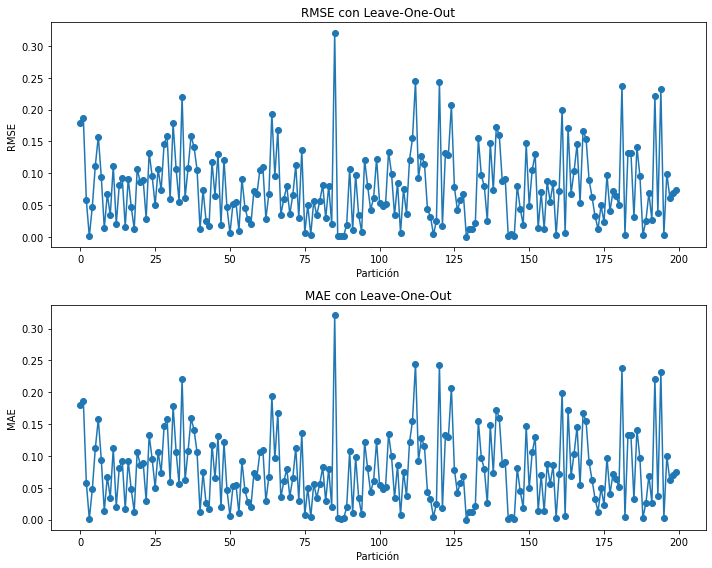

```python
fig, (ax1, ax2) = plt.subplots(2, 1, figsize=(10, 8))

ax1.plot(range(len(loo_rmse)), loo_rmse, marker='o')
ax1.set_title('RMSE con Leave-One-Out')
ax1.set_xlabel('Partición')
ax1.set_ylabel('RMSE')

ax2.plot(range(len(loo_mae)), loo_mae, marker='o')
ax2.set_title('MAE con Leave-One-Out')
ax2.set_xlabel('Partición')
ax2.set_ylabel('MAE')

plt.tight_layout()
plt.show()
```

## Para l@s más aplicados....

[figure not shown]

**Atrevete a experimentar con ellos en casa....**

**LeavePOut**: es como **KFold** pero al revés, se escogen P muestras del conjunto de test. Ojo porque esto no es equivalente a hacer `KFold(n_splits=n_samples // p)`. **LeavePOut** prueba todas las combinaciones posibles de P elementos para testear, dejando las restantes N-P muestras para entrenar. Esto tiene un muy alto coste computacional si la combinatoria de N elementos tomados en grupos de P es alta (y es fácil que lo sea).

`from sklearn.model_selection import LeavePOut`

**SuffleSplit**: parecido a **KFold** pero las particiones se generan de forma aleatoria

`from sklearn.model_selection import ShuffleSplit`